# Survey Analysis Demo

Analysis by Kyle Youngblood

# Current Members

| Motivation for joining (This Organization) - Ranked | Ranking |
| --- | --- |
| Learning from other executive directors | 1 |
| Networking opportunities with peer EDs | 1 |
| Encouragement and support from peers | 3 |
| Access to Community and City leaders | 4 |
| Learning from speakers | 5 |
| Resource sharing | 6 |

**Some other notable reasons to join (This Organization) included:**

- Board Member Suggestion
- To help other newer Executive Directors
- Local city resources
- As a new ED and new to the this area, was an exceptional opportunity to begin to meet colleagues and learn more about what else is happening in this area. has been a valuable source of information and support with problem solving

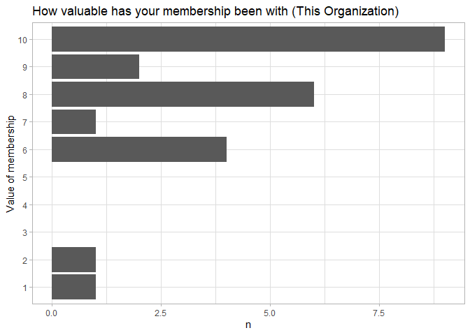

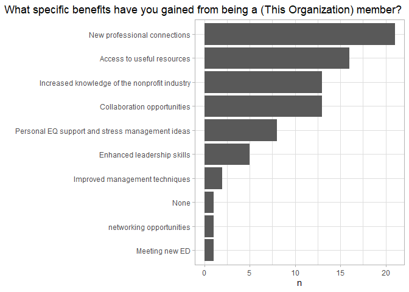

## Member – Attended Meetings

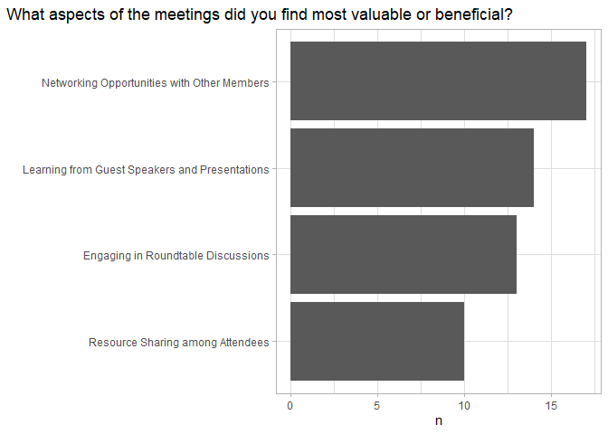

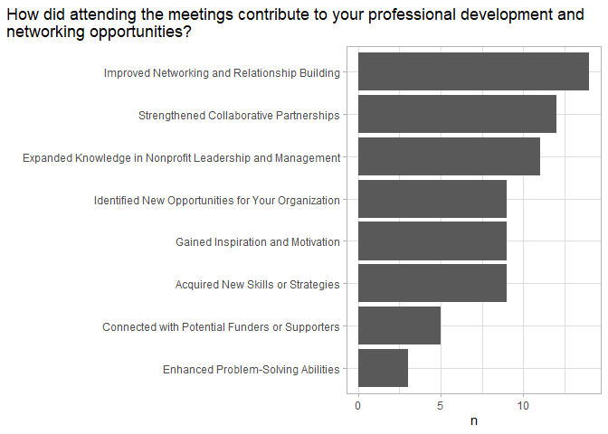

**Were there any specific guest speakers or topics that particularly resonated with you?**

- Speaker1’s topic on burnout was impactful.
- Enjoyed hearing from Speaker2 and Speaker3 very much
- Speaker4’s presentation was outstanding and very practical and applicable.
- Burnout session
- Really liked the presentation on burnout
- Burn Out, Meet the New City Manager
- Enjoyed the Tournament1 because it showed what that organization was being successful in doing. Too often we talk about what is not working, let’s talk about what is working and learn from that.
- (This Area) Community Foundation and City Manager
- burn out was a great topic
- No… I enjoyed all of them and took something away from each one.
- Presentation on Burnout was excellent.
- Succession planning

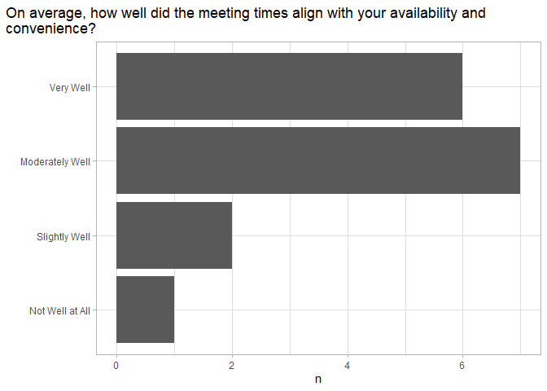

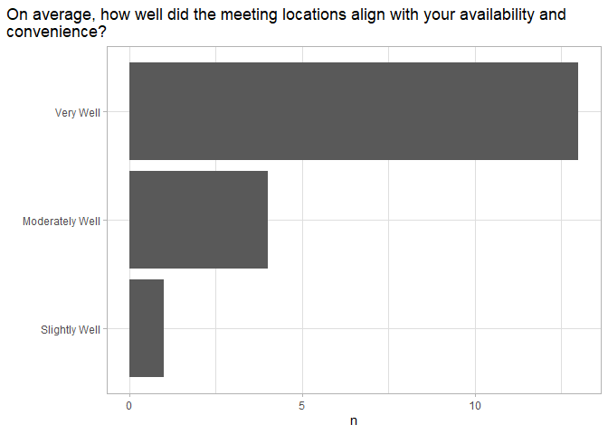

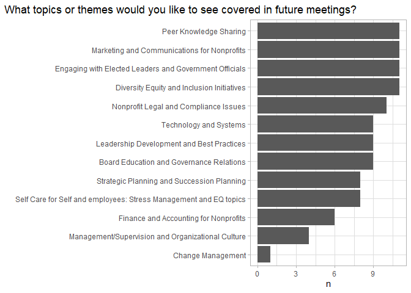

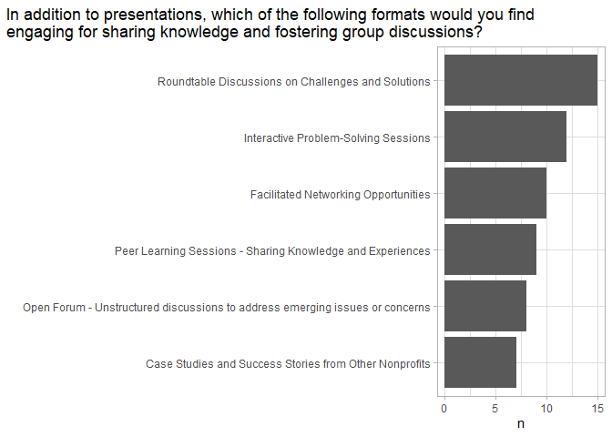

**Additional Comments from Members who attended meetings**

- I think the challenge with these meetings is facilitating them in such a way that no single member can dominate the conversation. We should create space for everyone to participate. Perhaps we could agree to set of principles to guide our meeting – that may include limiting the time you speak….
- I often can’t attend the Wednesday meetings unless I take a day off or go to work late. Wednesday’s coincides with my weekly staff virtual meetings. Other than that, I enjoy what I’ve been able to attend.
- Really appreciate this group. I look forward to each gathering for the support and encouragement.
- Would love include Arts and Culture ED’s
- With new leadership in both My Organization1 and My Organization2, it would be great to do a meet and greet with the new people are in place.
- Different venues to meet

## Member – Did not Attend Meetings

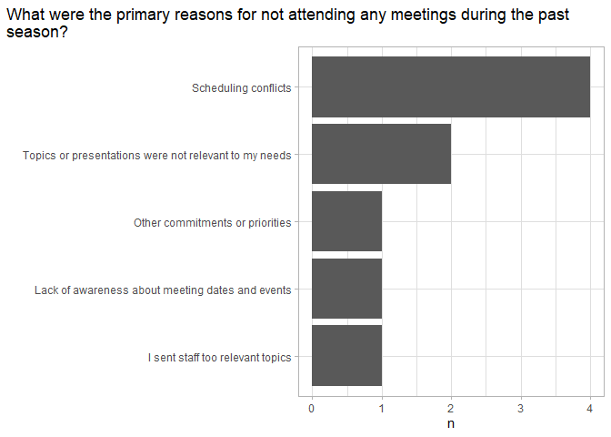

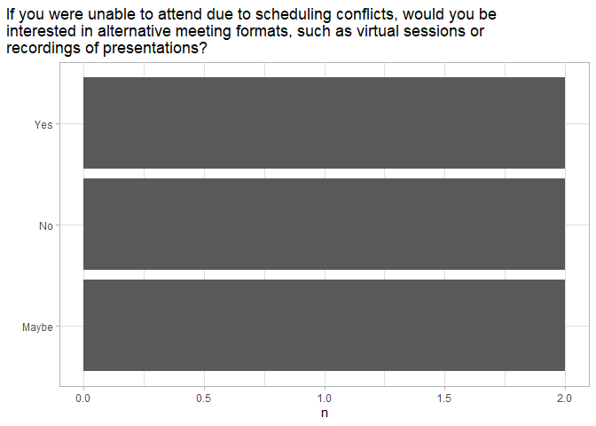

**Is there anything could do to make attending meetings more feasible or attractive to you?**

- Change time of day
- As a $30M organization, sometimes the issues don’t seem relevant.

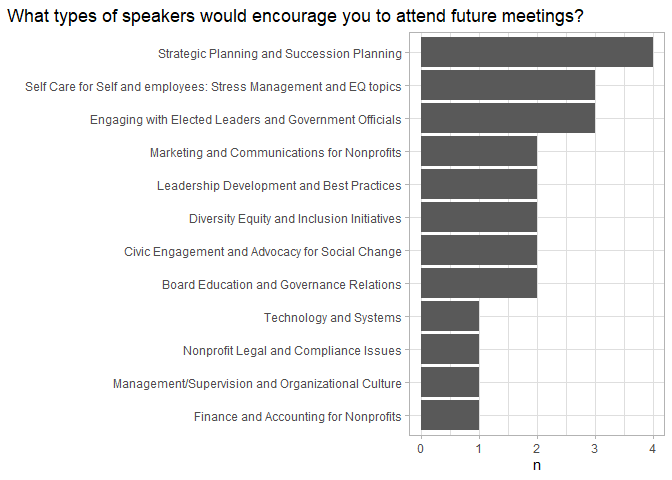

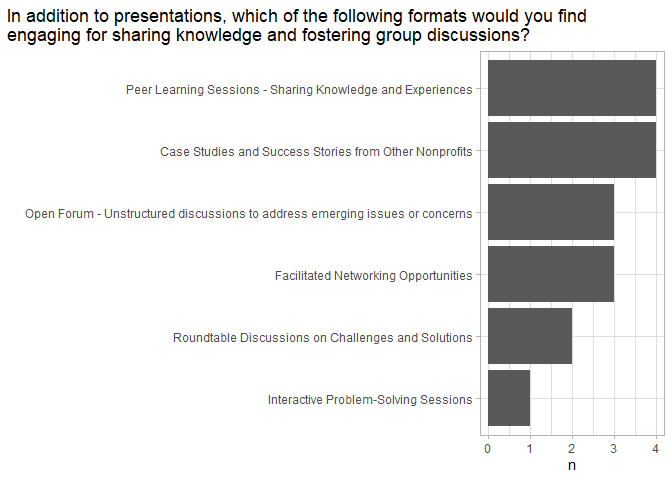

# Past member

| Motivation for joining (This Organization) - Ranked | Ranking |
| --- | --- |
| Learning from other executive directors | 1 |
| Presentations from guest speakers | 2 |
| Resource sharing | 2 |
| Networking opportunities | 4 |
| Encouragement and support from peers | 5 |

**Some other notable reasons to join included:**

- Raising organization’s visibility
- I was new in the city and wanted to understand how Non-Profits in Area function.

**If you have not renewed your membership, what are the main reasons for not renewing?**

- Schedule conflicts with meeting times x4
- Lack of perceived benefits x2
- Making time for meetings (not necessarily conflicts, just busy!)
- Limited relevance to my organization’s needs
- The group seems a bit elitist and there is a lack of diversity of thought and representation among ED’s in the city.

**What changes would make you interested in becoming a member again?**

- Perhaps quarterly meetings
- Communication
- New energy
- I think having a focus on reaching out to ALL types of non-profits in the city. I have spoken to ED’s in the city who have felt very unseen by because it seems like it’s only for the high society non-profits in this area.

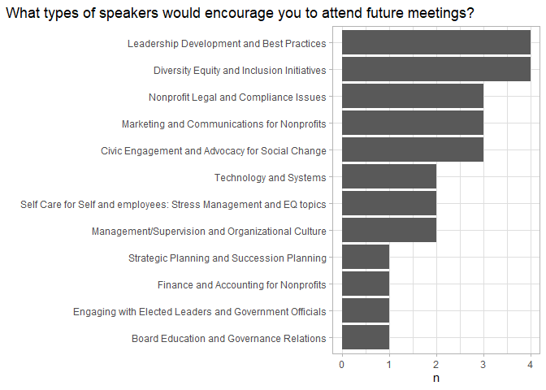

**Additional Comments from past Members**

- Maybe a more casual meeting format?

# Non Member

| What factors would compell a non member to join (This Organization) | Ranking |
| --- | --- |
| Learning from other executive directors | 1 |
| Networking opportunities | 2 |
| Resource sharing | 2 |
| Encouragement and support from peers | 4 |
| Presentations from guest speakers | 5 |

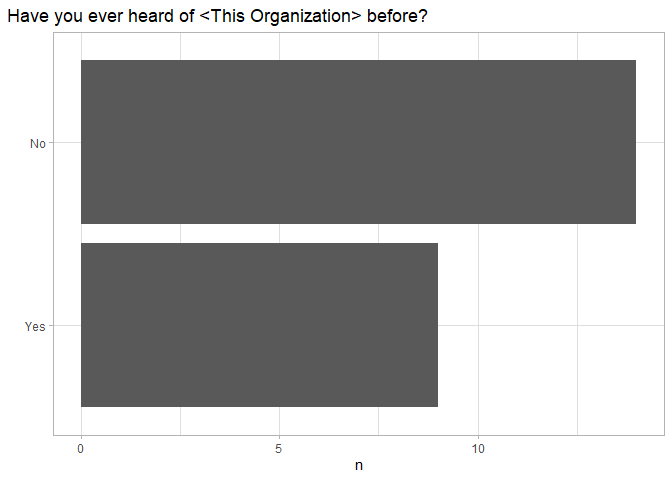

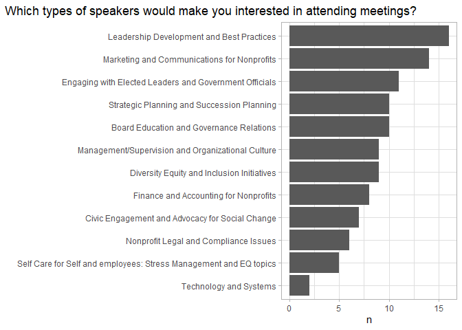

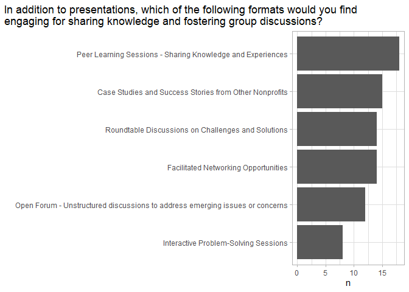

**Additional Comments from Non-Members**

- Grant writing opportunities and suggestions
- Can you check out the first meeting before signing up as a member?
- zoom availability
- Our organization serves the community members who are not able to get support from other agencies
- I would be interested in joining or at least start by attending an activity or two if it seems relevant to someone in my position as I described previously. Also I would be more inclined if there are BIPOC leaders in this group and I don’t know if that’s the case.